# DSW_2Assignment1

Data Science Workshop-2 (CSE 2196) ASSIGNMENT-1(PYTHON, DATA VISUALIZATION)

1. Differentiate between the followings with proper examples

a. all() vs any()

all()-Returns True if all items in an iterable object are true

```python
mylist = [True, True, True]
x = all(mylist)
print(x)
```

```
True
```

```python
mylist = [True, 0, True]
x = all(mylist)
print(x)
```

```
False
```

any()-Returns True if any item in an iterable object is true

```python
mylist = [False, True, False]
x = any(mylist)
print(x)
```

```
True
```

```python
mylist = [1,2,1]
x = any(mylist)
print(x)
```

```
True
```

b. dictionary vs default dictionary

Dictionary (dict):

A standard Python dictionary is a collection that stores unordered key-value pairs. Each key in a dictionary must be unique. When you try to access a key that doesn't exist in a standard dictionary, it raises a KeyError. Example:

```python
my_dict = {'abha': 1, 'bina': 2, 'ck': 3}
print(my_dict['abha'])
```

```
1
```

Default Dictionary (collections.defaultdict):

defaultdict is a subclass of the built-in dict class in the collections module. It allows you to provide a default value for each key. When you access a key that doesn't exist, it automatically creates the key and assigns it the default value. This avoids KeyError exceptions that you might encounter when using a standard dictionary. Example:

```python
from collections import defaultdict

# Define a defaultdict with default value as 0
my_defaultdict = defaultdict(int)
my_defaultdict['abha'] = 100
print(my_defaultdict['bina'])
```

```
0
```

c. *args and* *kwargs

*args: The* args parameter allows a function to accept any number of positional arguments. When a function is defined with *args, it can accept zero or more positional arguments. Inside the function, args becomes a tuple containing all the positional arguments passed to the function. Example:

```python
def my_function(*args):
    for arg in args:
        print(arg)

my_function(1, 2, 3)
my_function('abha', 'bina', 'ck', 'binoy')
```

```
1
2
3
abha
bina
ck
binoy
```

**kwargs:

The **kwargs parameter allows a function to accept any number of keyword arguments. When a function is defined with** kwargs, it can accept zero or more keyword arguments in the form of key=value pairs. Inside the function, kwargs becomes a dictionary containing all the keyword arguments passed to the function. Example:

```python
def my_function(**kwargs):
    for key, value in kwargs.items():
        print(f"{key}: {value}")

my_function(abha=19, bina=40, ck=17)
my_function(name='vivek', age=20)
```

```
abha: 19
bina: 40
ck: 17
name: vivek
age: 20
```

d. Data science vs data engineers

Data science and data engineering are two distinct but closely related fields within the broader domain of data analytics and management. Here's a brief comparison:

1. **Data Science**:
   - **Focus**: Data science primarily focuses on deriving insights and knowledge from data through analysis, modeling, and interpretation.
   - **Skills**: Data scientists typically possess skills in statistics, machine learning, data visualization, and domain expertise.
   - **Responsibilities**:
     - Cleaning and preprocessing data.
     - Exploratory data analysis (EDA) to understand data characteristics.
     - Building and training predictive models.
     - Extracting actionable insights from data.
   - **Tools**: Data scientists commonly use programming languages like Python or R, along with libraries such as pandas, scikit-learn, TensorFlow, and PyTorch.
   - **Goal**: The goal of data science is to extract value from data by uncovering patterns, making predictions, and informing decision-making processes.
2. **Data Engineering**:
   - **Focus**: Data engineering focuses on the design, construction, and maintenance of data pipelines and infrastructure for large-scale data processing and storage.
   - **Skills**: Data engineers typically possess skills in software engineering, database design, distributed systems, and cloud computing.
   - **Responsibilities**:
     - Building and maintaining data infrastructure (data warehouses, data lakes, ETL pipelines).
     - Developing scalable data processing systems.
     - Ensuring data quality and integrity.
     - Collaborating with data scientists and analysts to deploy models and enable data-driven decision-making.
   - **Tools**: Data engineers use a variety of tools and technologies, including SQL databases, NoSQL databases, distributed computing frameworks (e.g., Apache Spark), containerization (e.g., Docker), and cloud services (e.g., AWS, Azure, Google Cloud Platform).
   - **Goal**: The goal of data engineering is to provide a robust and efficient infrastructure for collecting, storing, and processing data, enabling data scientists and analysts to work effectively with large volumes of data.

In summary, while data scientists focus on extracting insights and building models to understand and predict phenomena, data engineers focus on building and maintaining the infrastructure necessary to support these activities at scale. Both roles are essential in the data-driven decision-making process, often working collaboratively to extract value from data.

2. Consider the data containing the salary and tenure of some employees. salaries and tenures = [(83000,

8.7), (88000, 8.1), (48000, 0.7), (76000, 6), (69000, 6.5), (76000, 7.5), (89000, 8.7), (60000, 1.8), (83000, 3.5),(68000, 8.1),(48000, 0.7), (63000, 1.8),(25000, 3.5)]

a. Find the average salary of each tenure

```python
salaries_and_tenures={
    83000:8.7,
    88000:8.1,
    48000:0.7,
    76000: 6,
    69000:6.5,
    76000:7.5,
    89000:8.7,
    60000:1.8,
    83000:3.5,
    68000:8.1,
    48000:0.7,
    63000:1.8,
    25000:3.5
}
print(salaries_and_tenures)
```

```
{83000: 3.5, 88000: 8.1, 48000: 0.7, 76000: 7.5, 69000: 6.5, 89000: 8.7, 60000: 1.8, 68000: 8.1, 63000: 1.8, 25000: 3.5}
```

```python
a=len(salaries_and_tenures)
sum=0
for x in salaries_and_tenures.keys():
    sum=sum+x
avg=sum/a
print(" The average salary of each tenure",avg)
```

```
 The average salary of each tenure 66900.0
```

b. Group together the salaries corresponding to the following bucket of tenures, less than two, between two and five, more than 5

```python
a1={}
a2={}
a3={}
for x,y in salaries_and_tenures.items():
    if y<2.0:
        a1=dict(salaries_and_tenures)
    elif x>=2.0 and x<=5.0:
        a2=dict(salaries_and_tenures)
    elif x>5.0:
        a3=dict(salaries_and_tenures)
print('The salaries corresponding to the following bucket of tenures')
print()
print("Less than 2 : ",a1)
print()
print("between 2 and 5",a2)
print()
print("more than 5",a3)
```

```
The salaries corresponding to the following bucket of tenures

Less than 2 :  {83000: 3.5, 88000: 8.1, 48000: 0.7, 76000: 7.5, 69000: 6.5, 89000: 8.7, 60000: 1.8, 68000: 8.1, 63000: 1.8, 25000: 3.5}

between 2 and 5 {}

more than 5 {83000: 3.5, 88000: 8.1, 48000: 0.7, 76000: 7.5, 69000: 6.5, 89000: 8.7, 60000: 1.8, 68000: 8.1, 63000: 1.8, 25000: 3.5}
```

```python
a1={}
a2={}
a3={}
sum_a1=0
sum_a2=0
sum_a3=0
for x,y in salaries_and_tenures.items():
    if y<2:
        a1=dict(salaries_and_tenures)
        sum_a1=sum_a1+x
        y1=len(salaries_and_tenures)
    if y>=2 and y<=5:
        a2=dict(salaries_and_tenures)
        sum_a2=sum_a2+x
        y2=len(salaries_and_tenures)
    if y>5:
        a3=dict(salaries_and_tenures)
        sum_a3=sum_a3+x
        y3=len(salaries_and_tenures)
avg_1=sum_a1/y1
avg_2=sum_a2/y2
avg_3=sum_a3/y3
print('Theaverage salary for each group(bucket of tenures)')
print()
print("Less than 2 : ",avg_1)
print()
print("between 2 and 5 : ",avg_2)
print()
print("more than 5 : ",avg_3)
```

```
Theaverage salary for each group(bucket of tenures)

Less than 2 :  17100.0

between 2 and 5 :  10800.0

more than 5 :  39000.0
```

# 3. Explain the use of assert statements in python, with an example.

The assert keyword is used when debugging code.

The assert keyword lets you test if a condition in your code returns True, if not, the program will raise an AssertionError.

```python
x = "hello"

#if condition returns True, then nothing happens:
assert x == "hello"
```

```python
#if condition returns False, AssertionError is raised:
assert x == "goodbye"
```

```
---------------------------------------------------------------------------
AssertionError                            Traceback (most recent call last)
Cell In[14], line 2
      1 #if condition returns False, AssertionError is raised:
----> 2 assert x == "goodbye"

AssertionError:
```

# 4. Count frequencies of various alphabets (Convert upper case into lower case and input given by user), plot the results for this as a bar chart with x-axis being the letter and y-axis as the corresponding frequency.

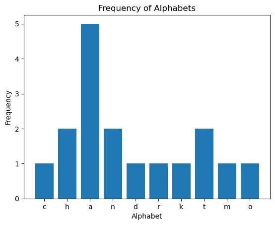

```python
import matplotlib.pyplot as plt
from collections import defaultdict
word=input("Enter a word : ")
def count_alphabet_frequencies(word):
    lower_case=word.lower()
    frequencies = defaultdict(int)

     # Count frequencies
    for char in lower_case:
        if char.isalpha():
            frequencies[char] += 1

    return frequencies
alphabet_frequencies = count_alphabet_frequencies(word)

# Extract data for plotting
letters = list(alphabet_frequencies.keys())
frequencies = list(alphabet_frequencies.values())

# Plotting the results

plt.bar(letters, frequencies)
plt.xlabel('Alphabet')
plt.ylabel('Frequency')
plt.title('Frequency of Alphabets')
plt.show()
```

### 5.Download the following data Company sales data.csv. Draw a line plot between month numbers and company’s profit per month. Give the X-axis name as ’Months’ and Y-axis name as ’Profit’. Give the at the top left corner.

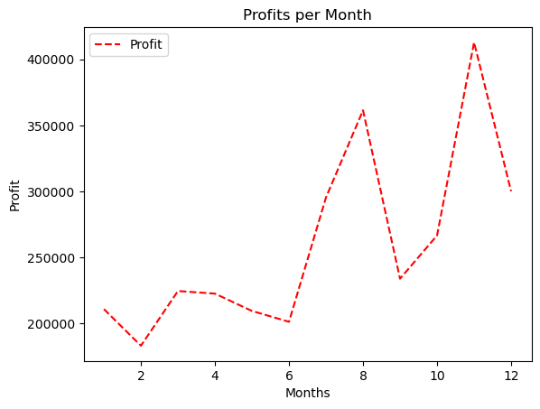

```python
import pandas as pd
import matplotlib.pyplot as plt

data = pd.read_csv("C:\\Users\\abham\\Downloads\\FMCG.csv")

# Extract month numbers and profit
months = data['month_number']
profits = data['total_profit']

# Create the line plot

plt.plot(months, profits, linestyle='--', color='red', label='Profit')
plt.xlabel('Months')
plt.ylabel('Profit')
plt.title('Profits per Month')
plt.legend(loc='upper left')

# Show the plot
plt.show()
```

### 6. Read all product sales data and show it using a multiline plot Display the number of units sold permonth for each product using multiline plots. (i.e., Separate Plot line for each product ). Keep thelegend on the top left corner.

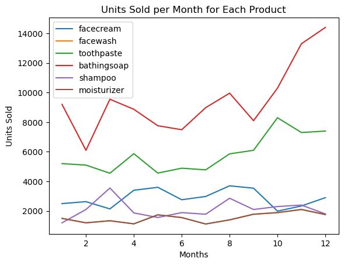

```python
product_columns = data.columns[1:-2]
for product in product_columns:
    plt.plot(data['month_number'], data[product], label=product)
plt.xlabel('Months')
plt.ylabel('Units Sold')
plt.title('Units Sold per Month for Each Product')
plt.legend(loc='upper left')

# Show the plot
plt.show()
```

### 7. Calculate total sale data for last year for each product and show it using a Pie chart Note: In Pie chartdisplay Number of units sold per year for each product in percentage.

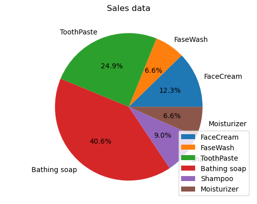

```python
import pandas as pd
import matplotlib.pyplot as plt


monthList  = data ['month_number'].tolist()

labels = ['FaceCream', 'FaseWash', 'ToothPaste', 'Bathing soap', 'Shampoo', 'Moisturizer']
salesData   = [data ['facecream'].sum(), data ['facewash'].sum(), data ['toothpaste'].sum(),
         data ['bathingsoap'].sum(), data ['shampoo'].sum(), data ['moisturizer'].sum()]

plt.axis("equal")
plt.pie(salesData, labels=labels, autopct='%1.1f%%')
plt.legend(loc='lower right')
plt.title('Sales data')

plt.show()
```